# Part II - Prosper Loan Data

## by Nahayo Gilbert

## Investigation Overview

> The overall goal was to understand different variables of Prosper loan data and charateristics of loan, and they both include who are the people who request the loans and how are the loans being paid back. And the key insights shows how Prosper rating is associated with providing Prosper loan.

## Dataset Overview

> Prosper is a peer-to-peer lending platform that lets borrowers access personal loans. Borrower qualifications are more accessible than many other online lenders. The data set contains 113,937 loans with 81 variables on each loan.

## Borrower's Employment Status

The graph shows different categories of people who request prosper loan and the majority of them are full-time employed.

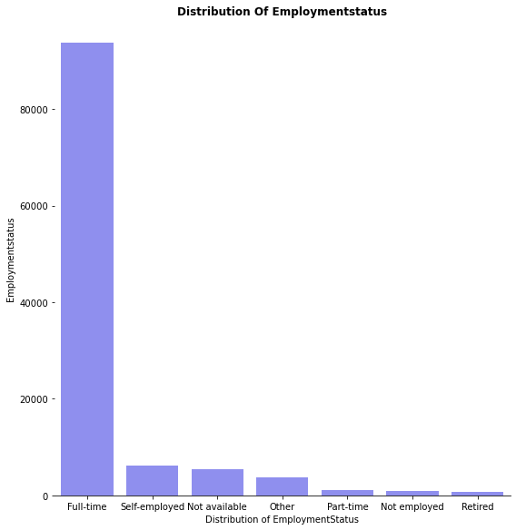

## Stated Monthly Income Distribution

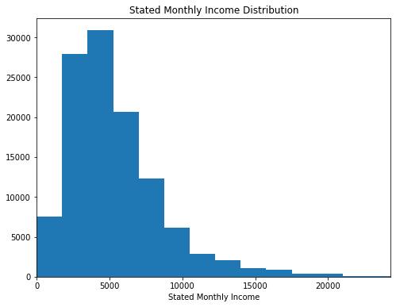

## Loan status in first 3 states

Let's see how loan is bein paid off in the three states which has high percentage of loans.

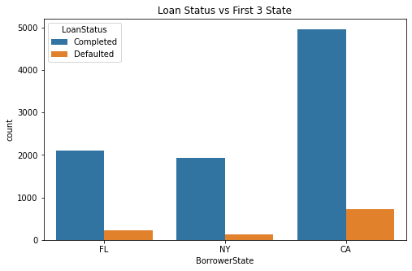